# DATA605 ASSIGNMENT 13

```r
library(tidyverse)
library(tidymodels)
library(gridExtra)
```

# 1 Question 1

**Use integration by substitution to solve the integral below.**
$$\int 4e^{-7x}dx$$

**Answer:**

Let $u=-7x$

then $du=-7dx$

then $\int 4e^{-7x}dx = -\frac{4}{7} \int e^{u}du= -\frac{4}{7}e^u+C=-\frac{4}{7}e^{-7x}+C \;\;\;\;where\;c\;is\;a\;constant$

# 2 Question 2

**Biologists are treating a pond contaminated with bacteria. The level of contamination is changing at a rate of** $\frac{dN}{dt}=-\frac{3150}{t^4}-220\;$ **bacteria per cubic centimeter per day, where t is the number of days since treatment began. Find a function** $N(t)\;$**to estimate the level of contamination if the level after 1 day was 6530 bacteria per cubic centimeter.**

**Answer:**

$N(t)=\int (-3150t^{-4}-220)dt=\int-3150t^{-4}dt-\int220dt$

$=\frac{3150}{3}t^{-3}-220t+C = 1050t^{-3}-220t+C\;\;\;where\;C\;is\;a\;constant$

$\because N(1)=6530$

$\therefore 1050(1)^{-3}-220(1)+C=6530$

$\therefore C=6530+220-1050=5700$

$\therefore N(t)=1050t^{-3}-220t+5700$

# 3 Question 3

**Find the total area of the red rectangles in the figure below, where the 3. equation of the line is** $f(X)=2x-9$

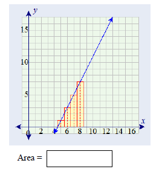

**Answer:**

$S = \int_{4.5}^{8.5}(2x-9)dx=\int_{4.5}^{8.5}2xdx-\int_{4.5}^{8.5}9dx$

$=8.5^2-4.5^2-9(8.5)+9(4.5)=16$

# 4 Question 4

**Find the area of the region bounded by the graphs of the given equations.**

$$y=x^2-2x-2,\;y=x+2$$

**Enter your answer below.**

**Answer:**

1. Plot the two functions

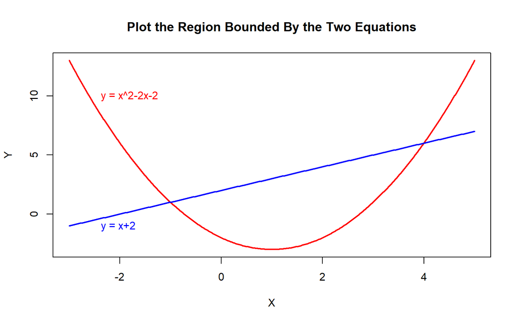

```r
eq1 = function(x){x^2-2*x-2}
eq2 = function(x){x+2}

curve(eq1, from=-3, to=5, n=300, xlab="X", ylab="Y", col="red",lwd=2,
      main="Plot the Region Bounded By the Two Equations",)

curve(eq2, from=-3, to=5, n=300, xlab="X", ylab="Y", col="blue",lwd=2,
      main="Plot the Region Bounded By the Two Equations", add = TRUE)

text(-2.5,10,"y = x^2-2x-2", pos=4, col = 'red')

text(-2.5,-1,"y = x+2", pos=4, col = 'blue')
```

2. Solve for Intersections

Let $x^2-2x-2=x+2$

Then $x^2-3x-4=0$

Then $(x-4)(x+1)=0$

Then $x_{1}=-1, \;x_{2}=4$

3. Solve for Area

$S = \int_{-1}^{4} x+2dx-\int_{-1}^{4} x^2-2x-2dx = \int_{-1}^{4} - x^2+3x+4dx$

$=-\frac{1}{3}(4^3-(-1)^3)+\frac{3}{2}(4^2-(-1)^2)+4(4-(-1))$

$=20.8333$

# 5 Question 5

**A beauty supply store expects to sell 110 flat irons during the next year. It costs $3.75 to store one flat iron for one year. There is a fixed cost of $8.25 for each order. Find the lot size and the number of orders per year that will minimize inventory costs.**

**Answer:**

Let c as the inventory cost, s the lot size, n the number of orders, and assume that half of the inventory are in stock,

To find n that minimize c, let

${c}'= -206.25n^{-2}+8.25 = 0$

$n_{min} = 5$

then $s_{min} = =22 $ and

$c_{min}=8.25(5)+206.25(5)^{-1}=82.5$

# 6 Question 6

**Use integration by parts to solve the integral below.**

$$\int ln(9x).x^6dx$$

**Answer:**

let $u=ln(9x),\;dv=x^6dx$

then $du = \frac{1}{9x}(9)dx=x^{-1}dx,\;v=\frac{1}{7}x^7$

then $\int ln(9x).x^6dx = \int udv=uv-\int vdu$

$=\frac{1}{7}ln(9x)x^7-\int \frac{1}{7}x^7x^{-1}dx$

$=\frac{1}{7}ln(9x)x^7-\frac{1}{7}\int x^6dx$

$=\frac{1}{7}ln(9x)x^7-\frac{1}{49}x^7+C$

$=\frac{1}{7}x^7(ln(9x)-\frac{1}{7})+C\;where\;C\;is\;a\;constant.$

# 7 Question 7

**Determine whether f ( x ) is a probability density function on the interval** $[1, \;e^6]\;$**. If not, determine the value of the definite integral.**

$$f(x)=\frac{1}{6x}$$

1. $\because x \in [1,\;e^6]$

$\therefore x > 0$

$\therefore f(x) >0$

2. $\because \int f(x)dx=\frac{1}{6}\int_{1}^{e^6} x^{-1}dx=\frac{1}{6}(ln(e^6)-ln(1))=\frac{1}{6}(6)=1$

$\therefore$ all values of (x) sum to 1.

Therefore f(x) is a probability density function.